# Bike Sharing Demand

## * 대회 링크 : https://www.kaggle.com/c/bike-sharing-demand/overview

- 대회 목표 :

  > 도시 전역에 있는 키오스크 네트워크를 통해 자전거 대여 데이터를 자동으로 수집하는 자전거 공유 시스템 데이터를 활용하여 워싱턴 D.C. 'Capital Bikeshare Program'의 자전거 대여 수요를 예측.
- 대회 평가 지표 : root mean squared logarithmic error (RMSLE).

# [ 파일 설명 ]

- train.csv : 훈련 세트. 2011년 1월부터 2012년 12월까지 매월 1~19일 사이의 데이터.
- test.csv : 테스트 세트. 2011년 1월부터 2012년 12월까지 매월 20~31일 사이의 데이터.
- sampleSubmission.csv : 제출 파일. 테스트 세트에 해당되는 기간 동안의 자전거 총 대여 수를 예측해야 함.

# [ 데이터 설명 ]

- datetime : 'yyyy-mm-dd 형식의 날짜(hourly date)' + 'hh-mm-ss 형식의 시간(timestamp)'.
- season : 1 = 봄, 2 = 여름, 3 = 가을, 4 = 겨울.
- holiday : 공휴일. 즉 (workingday=0, holiday=1). cf) 주말 (workingday=0, holiday=0).
- workingday : 근무일(월, 화, 수, 목, 금). 즉 (workingday=1, holiday=0).
- weather :
- 1 : 맑음, 구름 적음, 부분적으로 흐림.
- 2 : 안개 + 흐림, 안개 + 부서진 구름, 안개 + 약간의 구름, 안개.
- 3 : 약한 눈, 약한 비 + 뇌우 + 흩어진 구름, 약한 비 + 흩어진 구름.
- 4 : 폭우 + 얼음 깔판 + 뇌우 + 안개, 눈 + 안개
- temp : 섭씨 온도.
- atemp : 체감 섭씨 온도.
- humidity : 상대 습도.
- windspeed : 풍속.
- casual : 등록되지 않은 사용자의 자전거 대여 수.
- registered : 등록된 사용자의 자전거 대여 수.
- count : 자전거 총 대여 수.

# [ 목차 ]

## 1. 데이터 불러오고 개략적으로 살펴보기

```
* 가. train, test, sub.
```

## 2. 데이터 전처리

```
* 가. 파생변수 생성.
```

## 3. 시각화

```
* 가. matplotlib.
* 나. seaborn.
```

## 4. 머신러닝

```
* 가. train_test_split.
* 나. 여러가지 머신러닝 모델.
    * ㄱ. k-최근접 이웃 - KNeighborsRegressor.
    * ㄴ. 선형모델 - LinearRegression, Lasso, Ridge.
    * ㄷ. 결정트리 - DecisionTreeRegressor.
    * ㄹ. 결정트리의 앙상블 - RandomForestRegressor, GradientBoostingRegressor.
```

## 5. 결론

```
* 가. 가장 성능이 좋은 모델 제출.
```

```python
'''
# Ignore  the warnings

import warnings

warnings.filterwarnings('always')
warnings.filterwarnings('ignore')
'''
```

# 1. 데이터 불러오고 개략적으로 살펴보기

## 가. train, test, sub

```python
import pandas as pd

train = pd.read_csv("train.csv")
test = pd.read_csv("test.csv")
sub = pd.read_csv("sampleSubmission.csv")
```

### ㄱ. 데이터 형태

```python
print(train.shape, test.shape, sub.shape, sep='\n\n')
```

```
(10886, 12)

(6493, 9)

(6493, 2)
```

### ㄴ. 특성(특징)(Feature)

```python
print(train.columns, test.columns, sub.columns, sep='\n\n')
```

```
Index(['datetime', 'season', 'holiday', 'workingday', 'weather', 'temp',
       'atemp', 'humidity', 'windspeed', 'casual', 'registered', 'count'],
      dtype='object')

Index(['datetime', 'season', 'holiday', 'workingday', 'weather', 'temp',
       'atemp', 'humidity', 'windspeed'],
      dtype='object')

Index(['datetime', 'count'], dtype='object')
```

### ㄷ. train

```python
train.head()
```

|  | datetime | season | holiday | workingday | weather | temp | atemp | humidity | windspeed | casual | registered | count |
| --- | --- | --- | --- | --- | --- | --- | --- | --- | --- | --- | --- | --- |
| 0 | 2011-01-01 00:00:00 | 1 | 0 | 0 | 1 | 9.84 | 14.395 | 81 | 0.0 | 3 | 13 | 16 |
| 1 | 2011-01-01 01:00:00 | 1 | 0 | 0 | 1 | 9.02 | 13.635 | 80 | 0.0 | 8 | 32 | 40 |
| 2 | 2011-01-01 02:00:00 | 1 | 0 | 0 | 1 | 9.02 | 13.635 | 80 | 0.0 | 5 | 27 | 32 |
| 3 | 2011-01-01 03:00:00 | 1 | 0 | 0 | 1 | 9.84 | 14.395 | 75 | 0.0 | 3 | 10 | 13 |
| 4 | 2011-01-01 04:00:00 | 1 | 0 | 0 | 1 | 9.84 | 14.395 | 75 | 0.0 | 0 | 1 | 1 |

### ㄹ. test

```python
test.head()
```

|  | datetime | season | holiday | workingday | weather | temp | atemp | humidity | windspeed |
| --- | --- | --- | --- | --- | --- | --- | --- | --- | --- |
| 0 | 2011-01-20 00:00:00 | 1 | 0 | 1 | 1 | 10.66 | 11.365 | 56 | 26.0027 |
| 1 | 2011-01-20 01:00:00 | 1 | 0 | 1 | 1 | 10.66 | 13.635 | 56 | 0.0000 |
| 2 | 2011-01-20 02:00:00 | 1 | 0 | 1 | 1 | 10.66 | 13.635 | 56 | 0.0000 |
| 3 | 2011-01-20 03:00:00 | 1 | 0 | 1 | 1 | 10.66 | 12.880 | 56 | 11.0014 |
| 4 | 2011-01-20 04:00:00 | 1 | 0 | 1 | 1 | 10.66 | 12.880 | 56 | 11.0014 |

### ㅁ. sub

```python
sub.head()
```

|  | datetime | count |
| --- | --- | --- |
| 0 | 2011-01-20 00:00:00 | 0 |
| 1 | 2011-01-20 01:00:00 | 0 |
| 2 | 2011-01-20 02:00:00 | 0 |
| 3 | 2011-01-20 03:00:00 | 0 |
| 4 | 2011-01-20 04:00:00 | 0 |

### ㅂ. 자료형

```python
print(train.dtypes, test.dtypes, sub.dtypes, sep='\n\n')
```

```
datetime       object
season          int64
holiday         int64
workingday      int64
weather         int64
temp          float64
atemp         float64
humidity        int64
windspeed     float64
casual          int64
registered      int64
count           int64
dtype: object

datetime       object
season          int64
holiday         int64
workingday      int64
weather         int64
temp          float64
atemp         float64
humidity        int64
windspeed     float64
dtype: object

datetime    object
count        int64
dtype: object
```

### ㅅ. 결측치

```python
print(train.isnull().sum(), test.isnull().sum(), sub.isnull().sum(), sep='\n\n')
```

```
datetime      0
season        0
holiday       0
workingday    0
weather       0
temp          0
atemp         0
humidity      0
windspeed     0
casual        0
registered    0
count         0
dtype: int64

datetime      0
season        0
holiday       0
workingday    0
weather       0
temp          0
atemp         0
humidity      0
windspeed     0
dtype: int64

datetime    0
count       0
dtype: int64
```

### ㅇ. 특성(특징)(Feature)별 중복되지 않는 data 개수

```python
train_columns = ['datetime', 'season', 'holiday', 'workingday', 'weather', 'temp', 'atemp', 'humidity', 'windspeed', 'casual', 'registered', 'count']
test_columns = ['datetime', 'season', 'holiday', 'workingday', 'weather', 'temp', 'atemp', 'humidity', 'windspeed']
sub_columns = ['datetime', 'count']

print("train")
for column1 in train_columns:
    print(f"{column1} :", len(train[column1].unique()), end='/ ')
print("\n")

print("test")
for column2 in test_columns:
    print(f"{column2} :", len(test[column2].unique()), end='/ ')
print("\n")

print("sub")
for column3 in sub_columns:
    print(f"{column3} :", len(sub[column3].unique()), end='/ ')
```

```
train
datetime : 10886/ season : 4/ holiday : 2/ workingday : 2/ weather : 4/ temp : 49/ atemp : 60/ humidity : 89/ windspeed : 28/ casual : 309/ registered : 731/ count : 822/

test
datetime : 6493/ season : 4/ holiday : 2/ workingday : 2/ weather : 4/ temp : 49/ atemp : 65/ humidity : 79/ windspeed : 27/

sub
datetime : 6493/ count : 1/
```

### ㅈ. 요약

```python
train.describe() # 수치형 데이터 요약.
```

|  | season | holiday | workingday | weather | temp | atemp | humidity | windspeed | casual | registered | count |
| --- | --- | --- | --- | --- | --- | --- | --- | --- | --- | --- | --- |
| count | 10886.000000 | 10886.000000 | 10886.000000 | 10886.000000 | 10886.00000 | 10886.000000 | 10886.000000 | 10886.000000 | 10886.000000 | 10886.000000 | 10886.000000 |
| mean | 2.506614 | 0.028569 | 0.680875 | 1.418427 | 20.23086 | 23.655084 | 61.886460 | 12.799395 | 36.021955 | 155.552177 | 191.574132 |
| std | 1.116174 | 0.166599 | 0.466159 | 0.633839 | 7.79159 | 8.474601 | 19.245033 | 8.164537 | 49.960477 | 151.039033 | 181.144454 |
| min | 1.000000 | 0.000000 | 0.000000 | 1.000000 | 0.82000 | 0.760000 | 0.000000 | 0.000000 | 0.000000 | 0.000000 | 1.000000 |
| 25% | 2.000000 | 0.000000 | 0.000000 | 1.000000 | 13.94000 | 16.665000 | 47.000000 | 7.001500 | 4.000000 | 36.000000 | 42.000000 |
| 50% | 3.000000 | 0.000000 | 1.000000 | 1.000000 | 20.50000 | 24.240000 | 62.000000 | 12.998000 | 17.000000 | 118.000000 | 145.000000 |
| 75% | 4.000000 | 0.000000 | 1.000000 | 2.000000 | 26.24000 | 31.060000 | 77.000000 | 16.997900 | 49.000000 | 222.000000 | 284.000000 |
| max | 4.000000 | 1.000000 | 1.000000 | 4.000000 | 41.00000 | 45.455000 | 100.000000 | 56.996900 | 367.000000 | 886.000000 | 977.000000 |

```python
train.describe(include='O')   # 범주형 데이터 요약.
```

|  | datetime |
| --- | --- |
| count | 10886 |
| unique | 10886 |
| top | 2011-12-15 05:00:00 |
| freq | 1 |

```python
test.describe()
```

|  | season | holiday | workingday | weather | temp | atemp | humidity | windspeed |
| --- | --- | --- | --- | --- | --- | --- | --- | --- |
| count | 6493.000000 | 6493.000000 | 6493.000000 | 6493.000000 | 6493.000000 | 6493.000000 | 6493.000000 | 6493.000000 |
| mean | 2.493300 | 0.029108 | 0.685815 | 1.436778 | 20.620607 | 24.012865 | 64.125212 | 12.631157 |
| std | 1.091258 | 0.168123 | 0.464226 | 0.648390 | 8.059583 | 8.782741 | 19.293391 | 8.250151 |
| min | 1.000000 | 0.000000 | 0.000000 | 1.000000 | 0.820000 | 0.000000 | 16.000000 | 0.000000 |
| 25% | 2.000000 | 0.000000 | 0.000000 | 1.000000 | 13.940000 | 16.665000 | 49.000000 | 7.001500 |
| 50% | 3.000000 | 0.000000 | 1.000000 | 1.000000 | 21.320000 | 25.000000 | 65.000000 | 11.001400 |
| 75% | 3.000000 | 0.000000 | 1.000000 | 2.000000 | 27.060000 | 31.060000 | 81.000000 | 16.997900 |
| max | 4.000000 | 1.000000 | 1.000000 | 4.000000 | 40.180000 | 50.000000 | 100.000000 | 55.998600 |

```python
sub.describe()
```

|  | count |
| --- | --- |
| count | 6493.0 |
| mean | 0.0 |
| std | 0.0 |
| min | 0.0 |
| 25% | 0.0 |
| 50% | 0.0 |
| 75% | 0.0 |
| max | 0.0 |

# 2. 데이터 전처리

## 가. 파생변수 생성.

### ㄱ. 날짜형 자료형으로 데이터 다시 불러오기.

```python
train = pd.read_csv("train.csv", parse_dates=["datetime"])
test = pd.read_csv("test.csv", parse_dates=["datetime"])
```

```python
print(train.dtypes, test.dtypes, sep='\n\n')
```

```
datetime      datetime64[ns]
season                 int64
holiday                int64
workingday             int64
weather                int64
temp                 float64
atemp                float64
humidity               int64
windspeed            float64
casual                 int64
registered             int64
count                  int64
dtype: object

datetime      datetime64[ns]
season                 int64
holiday                int64
workingday             int64
weather                int64
temp                 float64
atemp                float64
humidity               int64
windspeed            float64
dtype: object
```

### ㄴ. 데이터 백업.

```python
new_train = train.copy()
new_test = test.copy()
```

```python
print(new_train.dtypes, new_test.dtypes, sep='\n\n')
```

```
datetime      datetime64[ns]
season                 int64
holiday                int64
workingday             int64
weather                int64
temp                 float64
atemp                float64
humidity               int64
windspeed            float64
casual                 int64
registered             int64
count                  int64
dtype: object

datetime      datetime64[ns]
season                 int64
holiday                int64
workingday             int64
weather                int64
temp                 float64
atemp                float64
humidity               int64
windspeed            float64
dtype: object
```

### ㄷ. 'year', 'month', 'day', 'hour', 'minute', 'second' feature 추가.

```python
new_train["year"] = new_train["datetime"].dt.year
new_train["month"] = new_train["datetime"].dt.month
new_train["day"] = new_train["datetime"].dt.day
new_train["hour"] = new_train["datetime"].dt.hour
new_train["minute"] = new_train["datetime"].dt.minute
new_train["second"] = new_train["datetime"].dt.second
```

```python
new_test["year"] = new_test["datetime"].dt.year
new_test["month"] = new_test["datetime"].dt.month
new_test["day"] = new_test["datetime"].dt.day
new_test["hour"] = new_test["datetime"].dt.hour
new_test["minute"] = new_test["datetime"].dt.minute
new_test["second"] = new_test["datetime"].dt.second
```

```python
print(new_train.columns, new_test.columns, sep='\n\n')
```

```
Index(['datetime', 'season', 'holiday', 'workingday', 'weather', 'temp',
       'atemp', 'humidity', 'windspeed', 'casual', 'registered', 'count',
       'year', 'month', 'day', 'hour', 'minute', 'second'],
      dtype='object')

Index(['datetime', 'season', 'holiday', 'workingday', 'weather', 'temp',
       'atemp', 'humidity', 'windspeed', 'year', 'month', 'day', 'hour',
       'minute', 'second'],
      dtype='object')
```

### ㄹ. 필요 없는 'datetime' feature 제거.

```python
new_train = new_train.drop(['datetime'], axis=1)
new_test = new_test.drop(['datetime'], axis=1)
```

```python
new_train.head(3)
```

|  | season | holiday | workingday | weather | temp | atemp | humidity | windspeed | casual | registered | count | year | month | day | hour | minute | second |
| --- | --- | --- | --- | --- | --- | --- | --- | --- | --- | --- | --- | --- | --- | --- | --- | --- | --- |
| 0 | 1 | 0 | 0 | 1 | 9.84 | 14.395 | 81 | 0.0 | 3 | 13 | 16 | 2011 | 1 | 1 | 0 | 0 | 0 |
| 1 | 1 | 0 | 0 | 1 | 9.02 | 13.635 | 80 | 0.0 | 8 | 32 | 40 | 2011 | 1 | 1 | 1 | 0 | 0 |
| 2 | 1 | 0 | 0 | 1 | 9.02 | 13.635 | 80 | 0.0 | 5 | 27 | 32 | 2011 | 1 | 1 | 2 | 0 | 0 |

```python
new_test.head(3)
```

|  | season | holiday | workingday | weather | temp | atemp | humidity | windspeed | year | month | day | hour | minute | second |
| --- | --- | --- | --- | --- | --- | --- | --- | --- | --- | --- | --- | --- | --- | --- |
| 0 | 1 | 0 | 1 | 1 | 10.66 | 11.365 | 56 | 26.0027 | 2011 | 1 | 20 | 0 | 0 | 0 |
| 1 | 1 | 0 | 1 | 1 | 10.66 | 13.635 | 56 | 0.0000 | 2011 | 1 | 20 | 1 | 0 | 0 |
| 2 | 1 | 0 | 1 | 1 | 10.66 | 13.635 | 56 | 0.0000 | 2011 | 1 | 20 | 2 | 0 | 0 |

# 3. 시각화

## 가. matplotlib

```python
import matplotlib.pyplot as plt
```

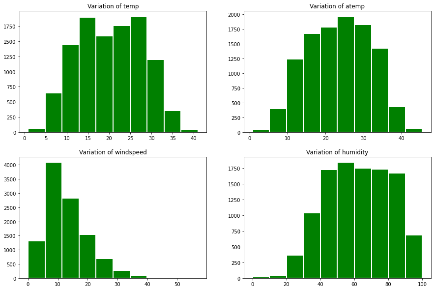

```python
fig, axes = plt.subplots(2,2, figsize=(10, 10), sharey=False) # figsize=(10, 10)) : 그래프 크기 설정.

axes[0,0].hist(x="temp",data=new_train, edgecolor='white', linewidth=2, color= 'green')
axes[0,0].set_title("Variation of temp")

axes[0,1].hist(x="atemp",data=new_train,edgecolor="white",linewidth=2,color='green')
axes[0,1].set_title("Variation of atemp")

axes[1,0].hist(x="windspeed",data=new_train,edgecolor="white",linewidth=2,color='green')
axes[1,0].set_title("Variation of windspeed")

axes[1,1].hist(x="humidity",data=new_train,edgecolor="white",linewidth=2,color='green')
axes[1,1].set_title("Variation of humidity")

fig.set_size_inches(15,10) # 그래프가 이미 생성된 경우 set_size_inches를 사용하여 그래프 크기 변경.
                           # cf). plt.figure(figsize=(7, 7)) : 그래프 크기 설정. (Default == 6, 4)
```

## 나. seaborn

### ㄱ. 캣플롯 (catplot)

```python
import seaborn as sns
```

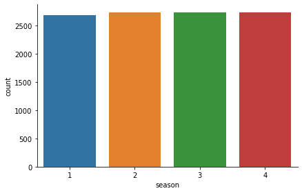

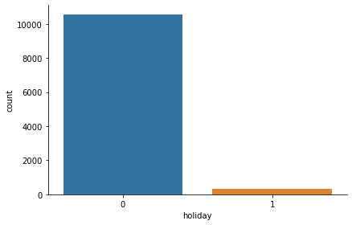

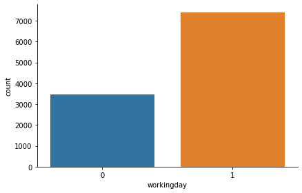

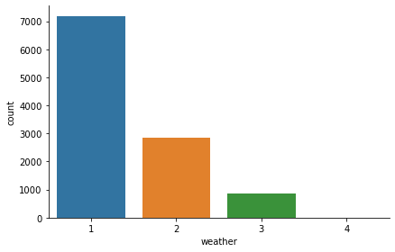

```python
# catplot : https://seaborn.pydata.org/generated/seaborn.catplot.html?highlight=catplot#seaborn.catplot

features = [ 'season', 'holiday', 'workingday', 'weather' ]
i=0

for feature in features:
    i+=1
    sns.catplot(x=feature,
                data=new_train,
                kind='count',   # countplot()
                height=4,       # 그래프 크기. default == 5
                aspect=1.5)     # 그래프 가로세로비. default == 가로:세로 = 1:aspect
plt.show()
```

### ㄴ. 박스플롯 (boxplot)

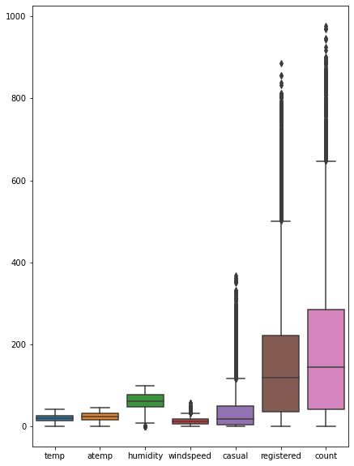

```python
sns.boxplot(data=new_train[ ['temp', 'atemp', 'humidity', 'windspeed',
                             'casual', 'registered', 'count'] ])

fig=plt.gcf() # matplotlib.pyplot.gcf() is primarily used to get the current figure.
              # If no current figure is available, then one is created with the help of the figure() function.

fig.set_size_inches(7,10)
```

```python
https://www.kaggle.com/rajmehra03/bike-sharing-demand-rmsle-0-3194
```